# DataAnalysis_finalreport

Author

Fanny Mulder

## Having a high glucose concentration increse the risk of having diabetes - the Fringham study

```r
library(gitcreds)
library(unibeCols)
library(usethis)
library(riskCommunicator)
library(tidyverse)
library(knitr)
library(rstatix)
data("framingham")
library(here)
```

In this study we will evaluate the correlation between glucose values and the risk of diabetes. We will first look at descriptive statistics of glucose in the framingham population such as the mean, the median, the 1st and the 3rd quartile. After this we will make the histogram of the distribution. We will also calculate the 95% interval for the mena of the glucose value. Then we want to analyse, if diabetic have another glucose value thant non-diabetic. Is the ditribution of the glucose value normal ? Is it there is a strong evidence against the null hypothesis ?

## Descriptive statistics

In this section, descriptive statistics will be displayed to better understand the risk of glucose on diabetes.

```r
sum(framingham$GLUCOSE)
```

```
[1] NA
```

```r
sum(is.na(framingham$GLUCOSE))
```

```
[1] 1440
```

```r
sum(framingham$GLUCOSE, na.rm = TRUE) / sum(!is.na(framingham$GLUCOSE))
```

```
[1] 84.12487
```

```r
mean_GLUC <- mean(framingham$GLUCOSE, na.rm = TRUE)
sorted_GLU <- sort(framingham$GLUCOSE)
sum(is.na(sorted_GLU))
```

```
[1] 0
```

```r
length(sorted_GLU)
```

```
[1] 10187
```

```r
mean_GLUC <- mean(framingham$GLUCOSE, na.rm =  TRUE)
middle_GLU <- (length(sorted_GLU) + 1) / 2
sorted_GLU[middle_GLU]
```

```
[1] 80
```

```r
median_GLU <- median(framingham$GLUCOSE, na.rm =  TRUE)
quart_GLU <- quantile(framingham$GLUCOSE, probs = c(0.25, 0.5, 0.75),
                      na.rm = TRUE)
sum((framingham$GLUCOSE - mean_GLUC) ^ 2, na.rm =  TRUE) /
  (sum(!is.na(framingham$GLUCOSE)) - 1)
```

```
[1] 624.6891
```

```r
var(framingham$GLUCOSE, na.rm =  TRUE)
```

```
[1] 624.6891
```

```r
sqrt(var(framingham$GLUCOSE, na.rm =  TRUE))
```

```
[1] 24.99378
```

```r
sd_GLU <- sd(framingham$GLUCOSE, na.rm =  TRUE)
max_GLU <- max(framingham$GLUCOSE, na.rm = T)
min_GLU <- min(framingham$GLUCOSE, na.rm = TRUE)
range(framingham$GLUCOSE, na.rm = TRUE)
```

```
[1]  39 478
```

```r
IQR(framingham$GLUCOSE, na.rm = TRUE)
```

```
[1] 17
```

```r
summary(framingham$GLUCOSE)
```

```
   Min. 1st Qu.  Median    Mean 3rd Qu.    Max.    NA's
  39.00   72.00   80.00   84.12   89.00  478.00    1440
```

### Histogram of the distribution of the glucose

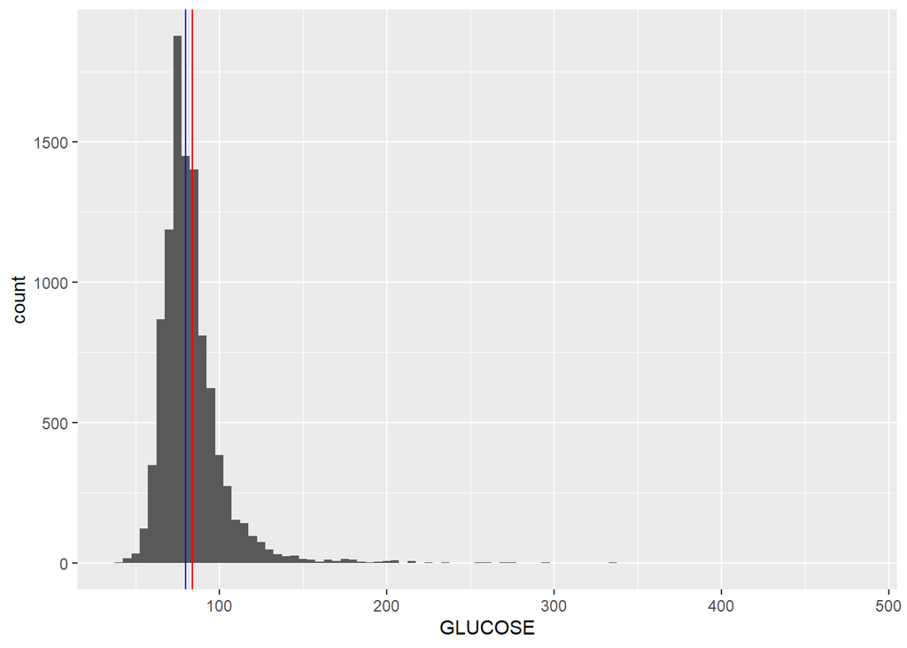

```r
ggplot(framingham, aes(x = GLUCOSE)) + geom_histogram(binwidth = 5) +
  geom_vline(xintercept = mean_GLUC, colour = "red") + geom_vline(xintercept = median_GLU, colour = "blue")
```

## Calculate the 95% confidence interval (CI) for the mean glucose value

```r
SE_GLU <- sd_GLU / sqrt(length(which(!is.na(framingham$GLUCOSE))))
zValue <- qnorm(0.975)
lowerCI_mean_GLU <- mean_GLUC - zValue * SE_GLU
upperCI_mean_GLU <- mean_GLUC + zValue * SE_GLU
cbind(mean_GLUC, lowerCI_mean_GLU, upperCI_mean_GLU)
```

```
     mean_GLUC lowerCI_mean_GLU upperCI_mean_GLU
[1,]  84.12487         83.63951         84.61022
```

```r
n <- length(which(!is.na(framingham$GLUCOSE)))
tQuantile <- qt(p = 0.975, df =  n - 1)
lowerCI_mean_GLU <- mean_GLUC - tQuantile * SE_GLU
upperCI_mean_GLU <- mean_GLUC + tQuantile * SE_GLU
```

## Gaphical comparison in the glucose value between diabetic and non-diabetic

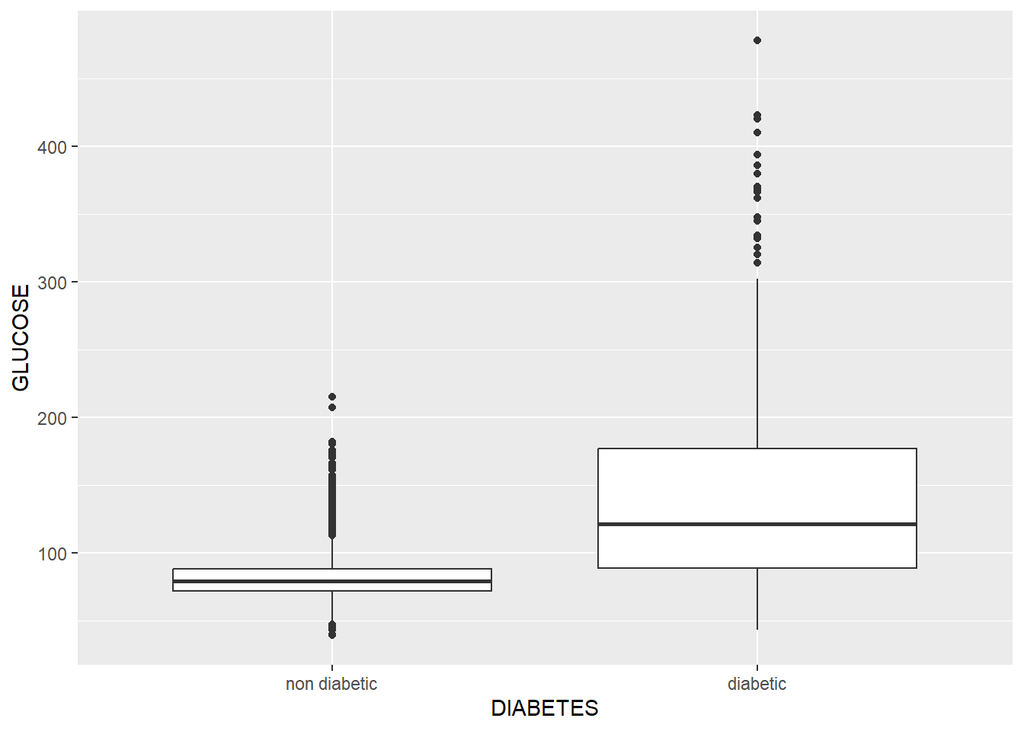

```r
framingham <- framingham |> mutate(DIABETES =factor(DIABETES, levels=c(0,1),labels=c("non diabetic","diabetic")))

ggplot(framingham, aes(y=GLUCOSE, x=DIABETES)) +
  geom_boxplot()
```

We can see that value of glucose in non diabetic is lower than the one of the diabetic. There is larger distribution in the diabetic population than in the non diabetic population.

## Non-normality

```r
head(framingham,5) |>
  kable()
```

| RANDID | SEX | TOTCHOL | AGE | SYSBP | DIABP | CURSMOKE | CIGPDAY | BMI | DIABETES | BPMEDS | HEARTRTE | GLUCOSE | educ | PREVCHD | PREVAP | PREVMI | PREVSTRK | PREVHYP | TIME | PERIOD | HDLC | LDLC | DEATH | ANGINA | HOSPMI | MI_FCHD | ANYCHD | STROKE | CVD | … |
| --- | --- | --- | --- | --- | --- | --- | --- | --- | --- | --- | --- | --- | --- | --- | --- | --- | --- | --- | --- | --- | --- | --- | --- | --- | --- | --- | --- | --- | --- | --- |
| 2448 | 1 | 195 | 39 | 106 | 70.0 | 0 | 0 | 26.97 | non diabetic | 0 | 80 | 77 | 4 | 0 | 0 | 0 | 0 | 0 | 0 | 1 | NA | NA | 0 | 0 | 1 | 1 | 1 | 0 | 1 | … |
| 2448 | 1 | 209 | 52 | 121 | 66.0 | 0 | 0 | NA | non diabetic | 0 | 69 | 92 | 4 | 0 | 0 | 0 | 0 | 0 | 4628 | 3 | 31 | 178 | 0 | 0 | 1 | 1 | 1 | 0 | 1 | … |
| 6238 | 2 | 250 | 46 | 121 | 81.0 | 0 | 0 | 28.73 | non diabetic | 0 | 95 | 76 | 2 | 0 | 0 | 0 | 0 | 0 | 0 | 1 | NA | NA | 0 | 0 | 0 | 0 | 0 | 0 | 0 | … |
| 6238 | 2 | 260 | 52 | 105 | 69.5 | 0 | 0 | 29.43 | non diabetic | 0 | 80 | 86 | 2 | 0 | 0 | 0 | 0 | 0 | 2156 | 2 | NA | NA | 0 | 0 | 0 | 0 | 0 | 0 | 0 | … |
| 6238 | 2 | 237 | 58 | 108 | 66.0 | 0 | 0 | 28.50 | non diabetic | 0 | 80 | 71 | 2 | 0 | 0 | 0 | 0 | 0 | 4344 | 3 | 54 | 141 | 0 | 0 | 0 | 0 | 0 | 0 | 0 | … |

### Histogram of glucose value

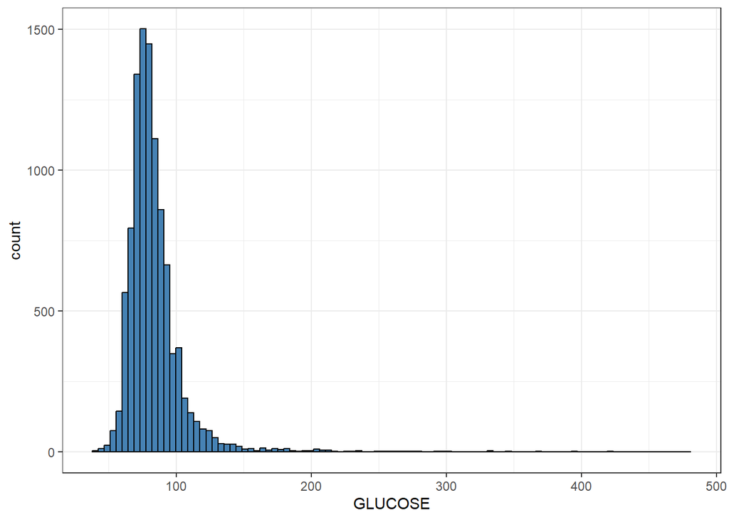

```r
framingham %>%
  ggplot(aes(GLUCOSE)) +
  geom_histogram(bins = 100,
                 color = "black",
                 fill = "steelblue") +
  theme_bw()
```

### Quantile-quantile plot

This quantile-quantile plot will allow us to assess the alignement and the theorical ligns.

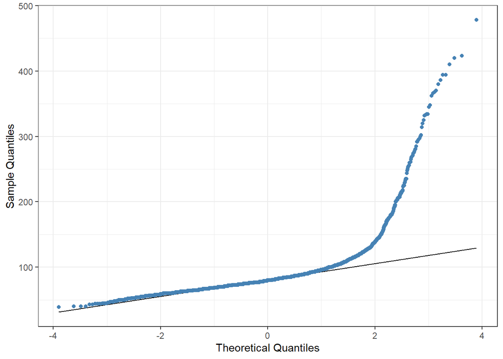

```r
framingham %>%
  ggplot(aes(sample = GLUCOSE)) +
  geom_qq_line(distribution = stats::qnorm) +
  geom_qq(color = "steelblue", distribution = stats::qnorm) +
  xlab("Theoretical Quantiles") +
  ylab("Sample Quantiles") +
  theme_bw()
```

We can see that the distribution is not normal.

```r
ks.test(framingham$GLUCOSE, "pnorm")
```

```
    Asymptotic one-sample Kolmogorov-Smirnov test

data:  framingham$GLUCOSE
D = 1, p-value < 2.2e-16
alternative hypothesis: two-sided
```

The distribution is not normal and there is a strong evidence against the null hypothesis.

## Logarithmic function

We are doing the logarithmic function to see, if with this function, it is normally distributed.

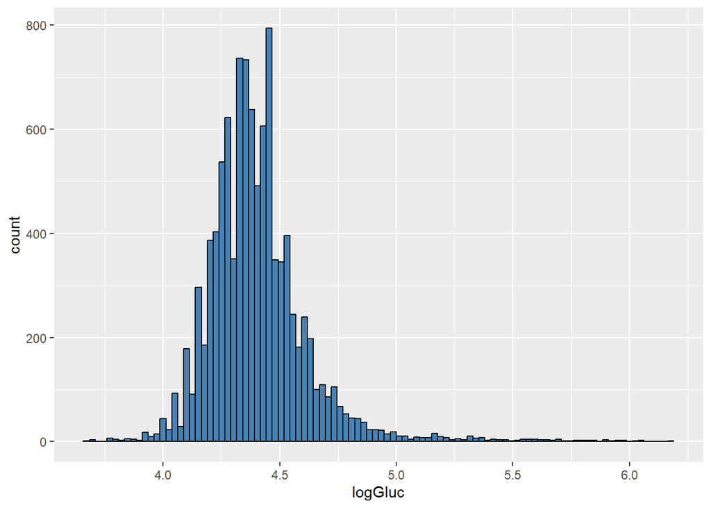

```r
framingham <- framingham |>
  mutate(logGluc = log(GLUCOSE))

ggplot(framingham, aes(x=logGluc)) + geom_histogram(bins = 100,
                 color = "black",
                 fill = "steelblue")
```

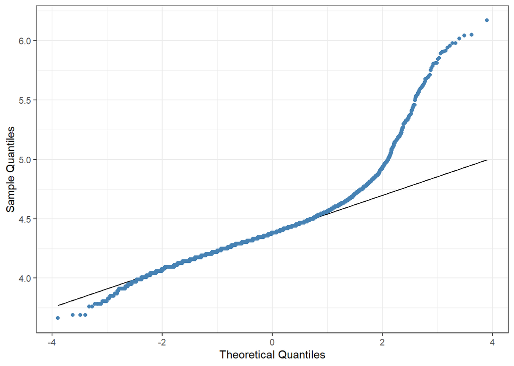

```r
framingham |>
  ggplot(aes(sample = logGluc)) +
  geom_qq_line(distribution = stats::qnorm) +
  geom_qq(color = "steelblue", distribution = stats::qnorm) +
  xlab("Theoretical Quantiles") +
  ylab("Sample Quantiles") +
  theme_bw()
```

```r
ks.test(framingham$logGluc, "pnorm")
```

```
    Asymptotic one-sample Kolmogorov-Smirnov test

data:  framingham$logGluc
D = 0.99988, p-value < 2.2e-16
alternative hypothesis: two-sided
```

Here again, the distribution is not normal and there is a strong evidence against the null hypothesis.

## Calculation if the mean glucose value differs between diabetics and non-diabetics.

```r
framingham %>%
  wilcox_test(GLUCOSE ~ DIABETES) %>%
  kable()
```

| .y. | group1 | group2 | n1 | n2 | statistic | p |
| --- | --- | --- | --- | --- | --- | --- |
| GLUCOSE | non diabetic | diabetic | 9744 | 443 | 788441.5 | 0 |

The difference between the means of the glucose values shows a strong evidence about having diabetes.